# Data 606 Lab 3

John Perez

2/25/2019

1. Make a histogram of men’s heights and a histogram of women’s heights. How would you compare the various aspects of the two distributions?

**Both distributions look fairly normal with slight skew.**

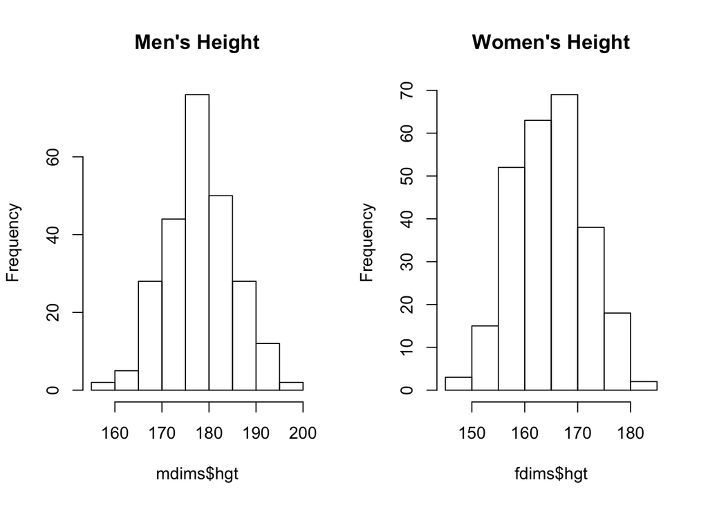

```r
par(mfrow=c(1,2))
hist(mdims$hgt, main="Men's Height")
hist(fdims$hgt,main="Women's Height")
```

**Yes, the data appears to follow a nearly normal distribution**

3. Make a normal probability plot of `sim_norm`. Do all of the points fall on the line? How does this plot compare to the probability plot for the real data?

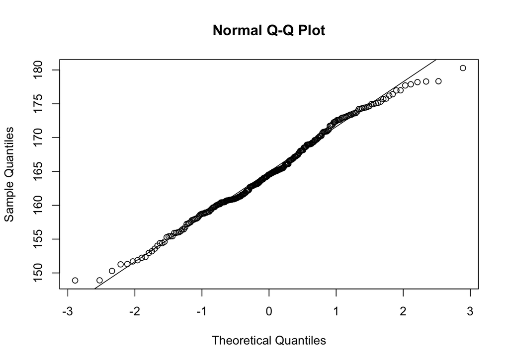

```r
set.seed(2112)
sim_norm <- rnorm(n = length(fdims$hgt), mean = fhgtmean, sd = fhgtsd)
qqnorm(sim_norm)
qqline(sim_norm)
```

4. Does the normal probability plot for `fdims$hgt` look similar to the plots created for the simulated data? That is, do plots provide evidence that the female heights are nearly normal?

5. Using the same technique, determine whether or not female weights appear to come from a normal distribution.

**It appears weight is skewed right, diverging from the normal distribution**

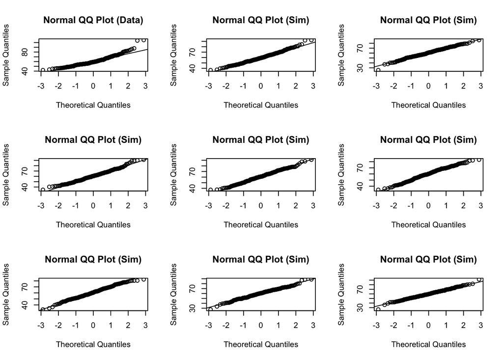

```r
set.seed(22)
qqnormsim(fdims$wgt)
```

6. Write out two probability questions that you would like to answer; one regarding female heights and one regarding female weights. Calculate the those probabilities using both the theoretical normal distribution as well as the empirical distribution (four probabilities in all). Which variable, height or weight, had a closer agreement between the two methods?

**What is the probability that a random female is shorter than 150cm?**  
**What is the probability that a random female is heavier than 68kg?**

```r
pnorm(150, fhgtmean, fhgtsd)
```

```
## [1] 0.01152955
```

```r
fwgtmean <- mean(fdims$wgt)
fwgtsd   <- sd(fdims$wgt)
1 - pnorm(68, fwgtmean, fwgtsd)
```

```
## [1] 0.2207879
```

## On Your Own

- **a.** This corresponds to plot B  
  **b.** This corresponds to plot C  
  **c.** This corresponds to plot D  
  **d.** This corresponds to plot A
- Note that normal probability plots C and D have a slight stepwise pattern.  
  Why do you think this is the case? **This could be caused by values being rounded**
- Make a normal probability plot for female knee diameter (`kne.di`). Based on this normal probability plot, is this variable left skewed, symmetric, or right skewed? Use a histogram to confirm your findings. **This variable is right skewed**

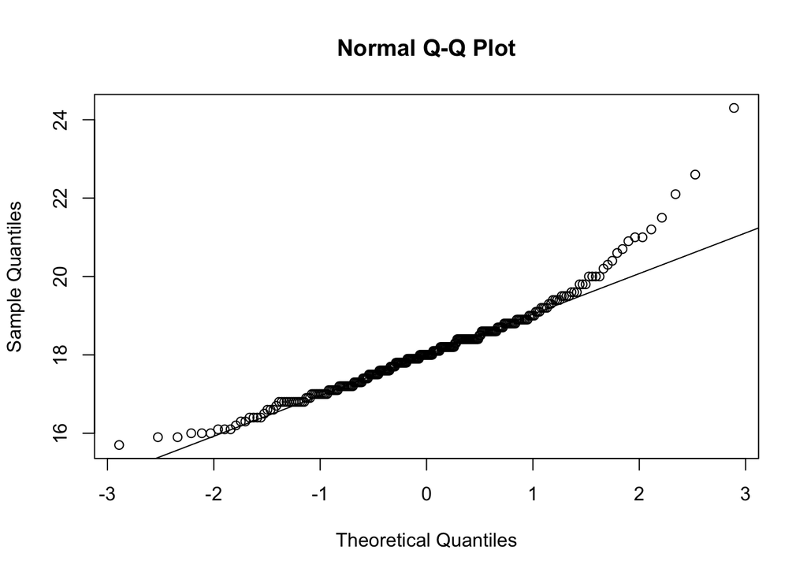

```r
#fkn <- fdims$kne.di
qqnorm(fdims$kne.di)
qqline(fdims$kne.di)
```

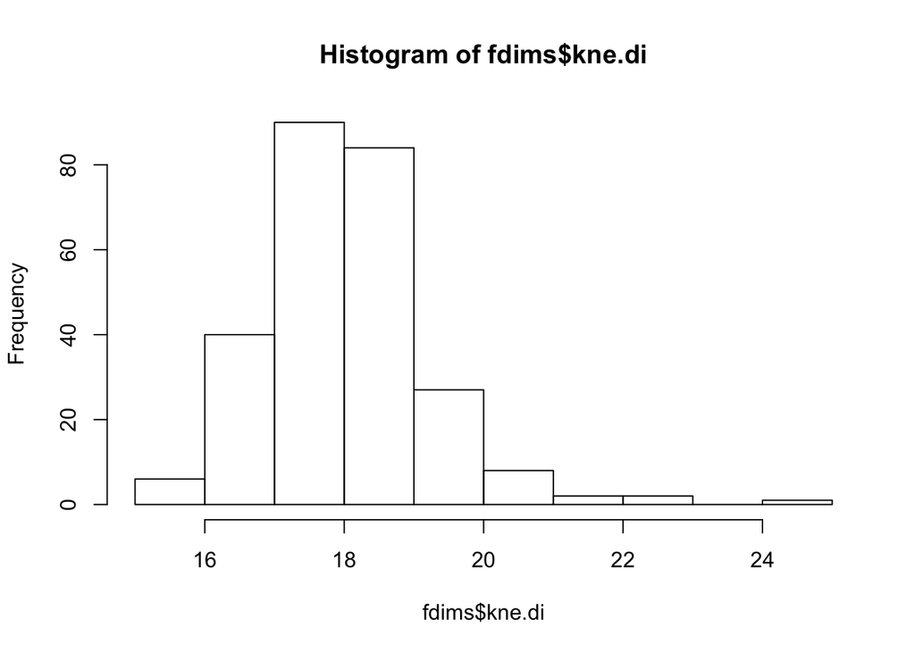

```r
hist(fdims$kne.di)
```